# Predict Bike Sharing Demand with AutoGluon Template

#### Initial score of `1.80753`

## Step 4: Exploratory Data Analysis and Creating an additional feature

- Any additional feature will do, but a great suggestion would be to separate out the datetime into hour, day, or month parts.

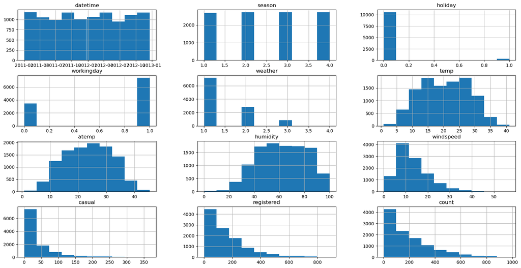

```python
# Create a histogram of all features to show the distribution of each one relative to the data. This is part of the exploritory data analysis
train.hist(figsize=(20,10));
```

```python
train.info()
```

```
<class 'pandas.core.frame.DataFrame'>
RangeIndex: 10886 entries, 0 to 10885
Data columns (total 12 columns):
 #   Column      Non-Null Count  Dtype
---  ------      --------------  -----
 0   datetime    10886 non-null  datetime64[ns]
 1   season      10886 non-null  int64
 2   holiday     10886 non-null  int64
 3   workingday  10886 non-null  int64
 4   weather     10886 non-null  int64
 5   temp        10886 non-null  float64
 6   atemp       10886 non-null  float64
 7   humidity    10886 non-null  int64
 8   windspeed   10886 non-null  float64
 9   casual      10886 non-null  int64
 10  registered  10886 non-null  int64
 11  count       10886 non-null  int64
dtypes: datetime64[ns](1), float64(3), int64(8)
memory usage: 1020.7 KB
```

```python
# create a new feature: on train data
train['year'] = train['datetime'].dt.year
train['month'] = train['datetime'].dt.month
train['day'] = train['datetime'].dt.day
train['hour'] = train['datetime'].dt.hour
train['weekday'] = train['datetime'].dt.weekday

# create a new feature: on test data
test['year'] = test['datetime'].dt.year
test['month'] = test['datetime'].dt.month
test['day'] = test['datetime'].dt.day
test['hour'] = test['datetime'].dt.hour
test['weekday'] = test['datetime'].dt.weekday
```

```python
train.drop(['datetime'], axis=1, inplace=True)
test.drop(['datetime'], axis=1, inplace=True)
```

```python
train.head()
```

|  | season | holiday | workingday | weather | temp | atemp | humidity | windspeed | casual | registered | count | year | month | day | hour | weekday |
| --- | --- | --- | --- | --- | --- | --- | --- | --- | --- | --- | --- | --- | --- | --- | --- | --- |
| 0 | 1 | 0 | 0 | 1 | 9.84 | 14.395 | 81 | 0.0 | 3 | 13 | 16 | 2011 | 1 | 1 | 0 | 5 |
| 1 | 1 | 0 | 0 | 1 | 9.02 | 13.635 | 80 | 0.0 | 8 | 32 | 40 | 2011 | 1 | 1 | 1 | 5 |
| 2 | 1 | 0 | 0 | 1 | 9.02 | 13.635 | 80 | 0.0 | 5 | 27 | 32 | 2011 | 1 | 1 | 2 | 5 |
| 3 | 1 | 0 | 0 | 1 | 9.84 | 14.395 | 75 | 0.0 | 3 | 10 | 13 | 2011 | 1 | 1 | 3 | 5 |
| 4 | 1 | 0 | 0 | 1 | 9.84 | 14.395 | 75 | 0.0 | 0 | 1 | 1 | 2011 | 1 | 1 | 4 | 5 |

```python
train.info()
```

```
<class 'pandas.core.frame.DataFrame'>
RangeIndex: 10886 entries, 0 to 10885
Data columns (total 16 columns):
 #   Column      Non-Null Count  Dtype
---  ------      --------------  -----
 0   season      10886 non-null  int64
 1   holiday     10886 non-null  int64
 2   workingday  10886 non-null  int64
 3   weather     10886 non-null  int64
 4   temp        10886 non-null  float64
 5   atemp       10886 non-null  float64
 6   humidity    10886 non-null  int64
 7   windspeed   10886 non-null  float64
 8   casual      10886 non-null  int64
 9   registered  10886 non-null  int64
 10  count       10886 non-null  int64
 11  year        10886 non-null  int32
 12  month       10886 non-null  int32
 13  day         10886 non-null  int32
 14  hour        10886 non-null  int32
 15  weekday     10886 non-null  int32
dtypes: float64(3), int32(5), int64(8)
memory usage: 1.1 MB
```

```python
test.head()
```

|  | season | holiday | workingday | weather | temp | atemp | humidity | windspeed | year | month | day | hour | weekday |
| --- | --- | --- | --- | --- | --- | --- | --- | --- | --- | --- | --- | --- | --- |
| 0 | 1 | 0 | 1 | 1 | 10.66 | 11.365 | 56 | 26.0027 | 2011 | 1 | 20 | 0 | 3 |
| 1 | 1 | 0 | 1 | 1 | 10.66 | 13.635 | 56 | 0.0000 | 2011 | 1 | 20 | 1 | 3 |
| 2 | 1 | 0 | 1 | 1 | 10.66 | 13.635 | 56 | 0.0000 | 2011 | 1 | 20 | 2 | 3 |
| 3 | 1 | 0 | 1 | 1 | 10.66 | 12.880 | 56 | 11.0014 | 2011 | 1 | 20 | 3 | 3 |
| 4 | 1 | 0 | 1 | 1 | 10.66 | 12.880 | 56 | 11.0014 | 2011 | 1 | 20 | 4 | 3 |

```python
test.info()
```

```
<class 'pandas.core.frame.DataFrame'>
RangeIndex: 6493 entries, 0 to 6492
Data columns (total 13 columns):
 #   Column      Non-Null Count  Dtype
---  ------      --------------  -----
 0   season      6493 non-null   int64
 1   holiday     6493 non-null   int64
 2   workingday  6493 non-null   int64
 3   weather     6493 non-null   int64
 4   temp        6493 non-null   float64
 5   atemp       6493 non-null   float64
 6   humidity    6493 non-null   int64
 7   windspeed   6493 non-null   float64
 8   year        6493 non-null   int32
 9   month       6493 non-null   int32
 10  day         6493 non-null   int32
 11  hour        6493 non-null   int32
 12  weekday     6493 non-null   int32
dtypes: float64(3), int32(5), int64(5)
memory usage: 532.8 KB
```

## Make category types for these so models know they are not just numbers

```python
# categorical feature
train['holiday'].value_counts()
```

```
holiday
0    10575
1      311
Name: count, dtype: int64
```

```python
# categorical feature
train['workingday'].value_counts()
```

```
workingday
1    7412
0    3474
Name: count, dtype: int64
```

```python
train["season"] = train['season'].astype('category')
train["weather"] = train['weather'].astype('category')
train['holiday'] = train['holiday'].astype('category')
train['workingday'] = train['workingday'].astype('category')
test["season"] = test['season'].astype('category')
test["weather"] = test['weather'].astype('category')
test['workingday'] = test['workingday'].astype('category')
test['holiday'] = test['holiday'].astype('category')
```

```python
train.info()
```

```
<class 'pandas.core.frame.DataFrame'>
RangeIndex: 10886 entries, 0 to 10885
Data columns (total 16 columns):
 #   Column      Non-Null Count  Dtype
---  ------      --------------  -----
 0   season      10886 non-null  category
 1   holiday     10886 non-null  category
 2   workingday  10886 non-null  category
 3   weather     10886 non-null  category
 4   temp        10886 non-null  float64
 5   atemp       10886 non-null  float64
 6   humidity    10886 non-null  int64
 7   windspeed   10886 non-null  float64
 8   casual      10886 non-null  int64
 9   registered  10886 non-null  int64
 10  count       10886 non-null  int64
 11  year        10886 non-null  int32
 12  month       10886 non-null  int32
 13  day         10886 non-null  int32
 14  hour        10886 non-null  int32
 15  weekday     10886 non-null  int32
dtypes: category(4), float64(3), int32(5), int64(4)
memory usage: 851.2 KB
```

```python
test.info()
```

```
<class 'pandas.core.frame.DataFrame'>
RangeIndex: 6493 entries, 0 to 6492
Data columns (total 13 columns):
 #   Column      Non-Null Count  Dtype
---  ------      --------------  -----
 0   season      6493 non-null   category
 1   holiday     6493 non-null   category
 2   workingday  6493 non-null   category
 3   weather     6493 non-null   category
 4   temp        6493 non-null   float64
 5   atemp       6493 non-null   float64
 6   humidity    6493 non-null   int64
 7   windspeed   6493 non-null   float64
 8   year        6493 non-null   int32
 9   month       6493 non-null   int32
 10  day         6493 non-null   int32
 11  hour        6493 non-null   int32
 12  weekday     6493 non-null   int32
dtypes: category(4), float64(3), int32(5), int64(1)
memory usage: 355.9 KB
```

```python
# View are new feature
train.head()
```

|  | season | holiday | workingday | weather | temp | atemp | humidity | windspeed | casual | registered | count | year | month | day | hour | weekday |
| --- | --- | --- | --- | --- | --- | --- | --- | --- | --- | --- | --- | --- | --- | --- | --- | --- |
| 0 | 1 | 0 | 0 | 1 | 9.84 | 14.395 | 81 | 0.0 | 3 | 13 | 16 | 2011 | 1 | 1 | 0 | 5 |
| 1 | 1 | 0 | 0 | 1 | 9.02 | 13.635 | 80 | 0.0 | 8 | 32 | 40 | 2011 | 1 | 1 | 1 | 5 |
| 2 | 1 | 0 | 0 | 1 | 9.02 | 13.635 | 80 | 0.0 | 5 | 27 | 32 | 2011 | 1 | 1 | 2 | 5 |
| 3 | 1 | 0 | 0 | 1 | 9.84 | 14.395 | 75 | 0.0 | 3 | 10 | 13 | 2011 | 1 | 1 | 3 | 5 |
| 4 | 1 | 0 | 0 | 1 | 9.84 | 14.395 | 75 | 0.0 | 0 | 1 | 1 | 2011 | 1 | 1 | 4 | 5 |

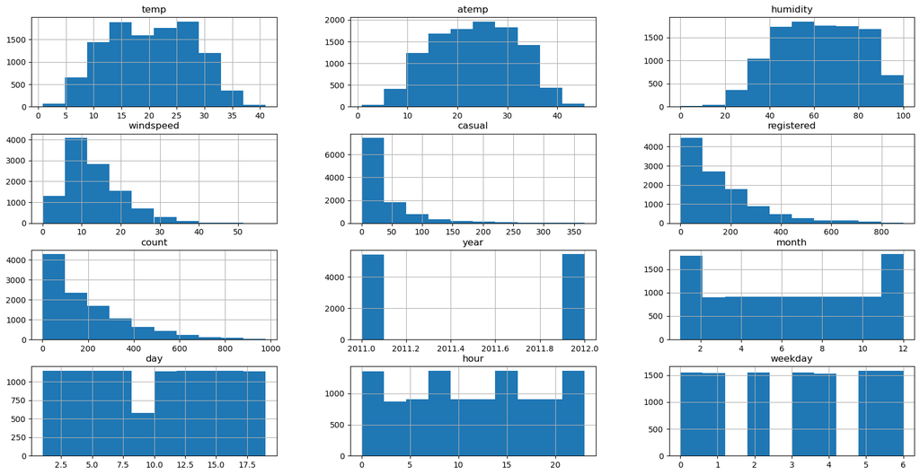

```python
# View histogram of all features again now with the hour feature
train.hist(figsize=(20,10));
```

## Step 5: Rerun the model with the same settings as before, just with more features

```python
predictor_new_features = TabularPredictor(label='count',
                             problem_type = 'regression',
                             eval_metric = 'root_mean_squared_error',
                             learner_kwargs = {'ignored_columns':["casual", "registered"]}).fit(
                                                                                                train_data = train,
                                                                                                time_limit=600,
                                                                                                presets='best_quality')
```

[output not shown]

[output cut: 86 more lines]

```
	-33.2323	 = Validation score   (-root_mean_squared_error)
	43.83s	 = Training   runtime
	0.77s	 = Validation runtime
Fitting model: CatBoost_BAG_L2 ... Training model for up to 16.63s of the 16.59s of remaining time.
	Fitting 8 child models (S1F1 - S1F8) | Fitting with ParallelLocalFoldFittingStrategy (2 workers, per: cpus=1, gpus=0, memory=0.75%)
	-33.2924	 = Validation score   (-root_mean_squared_error)
	25.89s	 = Training   runtime
	0.09s	 = Validation runtime
Fitting model: WeightedEnsemble_L3 ... Training model for up to 360.0s of the -16.1s of remaining time.
	Ensemble Weights: {'RandomForestMSE_BAG_L2': 0.318, 'LightGBMXT_BAG_L1': 0.227, 'LightGBM_BAG_L1': 0.182, 'LightGBM_BAG_L2': 0.091, 'CatBoost_BAG_L2': 0.091, 'RandomForestMSE_BAG_L1': 0.045, 'CatBoost_BAG_L1': 0.045}
	-32.5373	 = Validation score   (-root_mean_squared_error)
	0.07s	 = Training   runtime
	0.0s	 = Validation runtime
AutoGluon training complete, total runtime = 429.42s ... Best model: "WeightedEnsemble_L3"
TabularPredictor saved. To load, use: predictor = TabularPredictor.load("AutogluonModels/ag-20240505_043531")
```

```python
predictor_new_features.fit_summary()
```

```
*** Summary of fit() ***
Estimated performance of each model:
                     model   score_val              eval_metric  pred_time_val    fit_time  pred_time_val_marginal  fit_time_marginal  stack_level  can_infer  fit_order
0      WeightedEnsemble_L3  -32.537257  root_mean_squared_error      27.515301  358.462807                0.000683           0.070014            3       True         13
1      WeightedEnsemble_L2  -32.822972  root_mean_squared_error      25.219800  253.355448                0.001043           0.026037            2       True          8
2          LightGBM_BAG_L2  -33.157939  root_mean_squared_error      26.658127  288.673466                0.205190          26.367004            2       True         10
3   RandomForestMSE_BAG_L2  -33.232282  root_mean_squared_error      27.223294  306.134089                0.770357          43.827627            2       True         11
4          CatBoost_BAG_L2  -33.292401  root_mean_squared_error      26.539071  288.198162                0.086134          25.891701            2       True         12
5        LightGBMXT_BAG_L2  -33.725509  root_mean_squared_error      26.800930  289.675193                0.347993          27.368731            2       True          9
6          LightGBM_BAG_L1  -34.439520  root_mean_squared_error       5.089577   59.635482                5.089577          59.635482            1       True          4
7        LightGBMXT_BAG_L1  -34.771983  root_mean_squared_error      19.403486   86.927222               19.403486          86.927222            1       True          3
8          CatBoost_BAG_L1  -36.179969  root_mean_squared_error       0.109709   92.292021                0.109709          92.292021            1       True          6
9     ExtraTreesMSE_BAG_L1  -38.696212  root_mean_squared_error       0.788030    8.876008                0.788030           8.876008            1       True          7
10  RandomForestMSE_BAG_L1  -39.031652  root_mean_squared_error       0.615985   14.474685                0.615985          14.474685            1       True          5
11   KNeighborsDist_BAG_L1 -115.038459  root_mean_squared_error       0.234510    0.052019                0.234510           0.052019            1       True          2
12   KNeighborsUnif_BAG_L1 -119.978810  root_mean_squared_error       0.211639    0.049024                0.211639           0.049024            1       True          1
Number of models trained: 13
Types of models trained:
{'WeightedEnsembleModel', 'StackerEnsembleModel_XT', 'StackerEnsembleModel_CatBoost', 'StackerEnsembleModel_KNN', 'StackerEnsembleModel_LGB', 'StackerEnsembleModel_RF'}
Bagging used: True  (with 8 folds)
Multi-layer stack-ensembling used: True  (with 3 levels)
Feature Metadata (Processed):
(raw dtype, special dtypes):
('category', [])  : 2 | ['season', 'weather']
('float', [])     : 3 | ['temp', 'atemp', 'windspeed']
('int', [])       : 5 | ['humidity', 'month', 'day', 'hour', 'weekday']
('int', ['bool']) : 3 | ['holiday', 'workingday', 'year']
Plot summary of models saved to file: AutogluonModels/ag-20240505_043531SummaryOfModels.html
*** End of fit() summary ***
```

[output not shown]

[output cut: 114 more lines]

```

     stack_level  can_infer  fit_order
 0             3       True         13
 1             2       True          8
 2             2       True         10
 3             2       True         11
 4             2       True         12
 5             2       True          9
 6             1       True          4
 7             1       True          3
 8             1       True          6
 9             1       True          7
 10            1       True          5
 11            1       True          2
 12            1       True          1  }
```

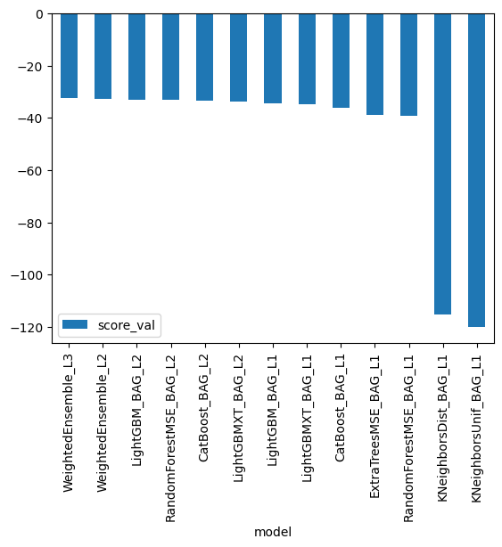

```python
# Leaderboard on graph
predictor_new_features.leaderboard(silent=True).plot(kind="bar", x="model", y="score_val")
```

```python
prediction_new_features = predictor_new_features.predict(test)
prediction_new_features.head()
```

```
0    14.840495
1     3.263856
2     2.168299
3     2.757370
4     2.476774
Name: count, dtype: float32
```

```python
prediction_new_features.describe()
```

```
count    6493.000000
mean      189.717346
std       173.425446
min        -7.676832
25%        46.600185
50%       147.860779
75%       277.818054
max       895.380676
Name: count, dtype: float64
```

```python
# How many negative values do we have?
negative_val = 0
positive_val = 0

for number in prediction_new_features:
    if number<0:
        negative_val +=1
    else:
        positive_val +=1

print(f"With the total {len(prediction_new_features)} predict_new_features, there are:\n  {negative_val} negative value and \n  {positive_val} positive value")
```

```
With the total 6493 predict_new_features, there are:
  17 negative value and
  6476 positive value
```

```python
# Remember to set all negative values to zero
for a, value in enumerate(prediction_new_features):
    if value <0:
        prediction_new_features[a]=0

prediction_new_features.describe()
```

```
count    6493.000000
mean      189.721619
std       173.420700
min         0.000000
25%        46.600185
50%       147.860779
75%       277.818054
max       895.380676
Name: count, dtype: float64
```

```python
# Same submitting predictions
submission_new_features = pd.read_csv('sampleSubmission.csv', parse_dates = ['datetime'])
submission_new_features["count"] = prediction_new_features
submission_new_features.to_csv("submission_new_features.csv", index=False)
```

```python
!kaggle competitions submit -c bike-sharing-demand -f submission_new_features.csv -m "new features review 1"
```

```
Successfully submitted to Bike Sharing Demand
```

```python
!kaggle competitions submissions -c bike-sharing-demand | tail -n +1 | head -n 6
```

```
fileName                     date                 description                        status    publicScore  privateScore
---------------------------  -------------------  ---------------------------------  --------  -----------  ------------
submission_new_features.csv  2024-05-05 04:53:52  new features review 1              complete  0.47464      0.47464
submission.csv               2024-05-05 04:13:46  first raw submission review 1      complete  1.80753      1.80753
submission.csv               2024-05-05 03:28:21  first raw submission               complete  1.80753      1.80753
submission_new_hpo.csv       2024-05-03 20:38:48  new features with hyperparameters  complete  0.47003      0.47003
```

#### New Score of `0.47464`

## Step 6: Hyper parameter optimization

- There are many options for hyper parameter optimization.
- Options are to change the AutoGluon higher level parameters or the individual model hyperparameters.
- The hyperparameters of the models themselves that are in AutoGluon. Those need the `hyperparameter` and `hyperparameter_tune_kwargs` arguments.

```python
#set up the parameter using more model
import autogluon.common as ag
#from autogluon.common import space

# Not consider ['NN_TORCH'] family of models
nn_options = {'num_epochs': 10,
              'learning_rate': ag.space.Real(1e-3, 1e-2, default=5e-3, log=True),# learning rate in training
              'activation': ag.space.Categorical('relu', 'softrelu', 'tanh'),# activation function in NN
              'dropout_prob': ag.space.Real(0.0, 0.4, default=0.2)}

# Considering GBM, KNN and XGB model types
# For GBM
gbm_options = { # Tune non default hyperparameter value
                'num_boost_round': 90,
                'num_leaves': ag.space.Int(lower=27, upper=54, default=32),  # number of leaves in trees
                }
# KNN Models
knn_options = {
                'weights': 'distance',
                'ag_args': {'name_suffix': 'Unif'}
                }

# XGB Models
xgb_options = {
                'objective': 'reg:squarederror',
                'eval_metric': 'rmse',
                'max_depth':ag.space.Int(lower=5, upper=8, default=6),
                'n_estimators': ag.space.Int(lower=100, upper=500, default=100),
                'eta':.3,
                'subsample': 1,
                'colsample_bytree': 1
                }

hyperparameters = {  # hyperparameters
                   'NN_TORCH': nn_options,
                   'GBM': gbm_options,
                   'KNN': knn_options,
                   'XGB': xgb_options
                  }

hyperparameter_tune_kwargs = {
                            'num_trials': 10,
                            'scheduler' : 'local',
                            'searcher': 'auto',
                        }
```

```python
predictor_new_hpo = TabularPredictor(label='count',
                                     problem_type='regression',
                                     eval_metric='root_mean_squared_error',
                                     learner_kwargs={'ignored_columns': ["casual", "registered"]}).fit(train_data=train,
                                                                         time_limit = 600,
                                                                         presets = 'best_quality',
                                                                         hyperparameters = hyperparameters,
                                                                         hyperparameter_tune_kwargs = hyperparameter_tune_kwargs)
```

[output not shown]

[output cut: 26 more lines]

```
{
	'NN_TORCH': {'num_epochs': 10, 'learning_rate': Real: lower=0.001, upper=0.01, 'activation': Categorical['relu', 'softrelu', 'tanh'], 'dropout_prob': Real: lower=0.0, upper=0.4},
	'GBM': {'num_boost_round': 90, 'num_leaves': Int: lower=27, upper=54},
	'KNN': {'weights': 'distance', 'ag_args': {'name_suffix': 'Unif'}},
	'XGB': {'objective': 'reg:squarederror', 'eval_metric': 'rmse', 'max_depth': Int: lower=5, upper=8, 'n_estimators': Int: lower=100, upper=500, 'eta': 0.3, 'subsample': 1, 'colsample_bytree': 1},
}
AutoGluon will fit 2 stack levels (L1 to L2) ...
Fitting 4 L1 models ...
Hyperparameter tuning model: KNeighborsUnif_BAG_L1 ... Tuning model for up to 72.55s of the 483.77s of remaining time.
	No hyperparameter search space specified for KNeighborsUnif_BAG_L1. Skipping HPO. Will train one model based on the provided hyperparameters.
Fitted model: KNeighborsUnif_BAG_L1 ...
	-115.0385	 = Validation score   (-root_mean_squared_error)
	0.37s	 = Training   runtime
	0.0s	 = Validation runtime
Hyperparameter tuning model: LightGBM_BAG_L1 ... Tuning model for up to 72.55s of the 483.28s of remaining time.
```

```
	Fitting 8 child models (S1F1 - S1F8) | Fitting with ParallelLocalFoldFittingStrategy (2 workers, per: cpus=1, gpus=0, memory=0.42%)
	Fitting 8 child models (S1F1 - S1F8) | Fitting with ParallelLocalFoldFittingStrategy (2 workers, per: cpus=1, gpus=0, memory=0.56%)
	Stopping HPO to satisfy time limit...
Fitted model: LightGBM_BAG_L1/T1 ...
	-43.7473	 = Validation score   (-root_mean_squared_error)
	29.38s	 = Training   runtime
	0.0s	 = Validation runtime
Fitted model: LightGBM_BAG_L1/T2 ...
	-37.8453	 = Validation score   (-root_mean_squared_error)
	26.26s	 = Training   runtime
	0.0s	 = Validation runtime
Hyperparameter tuning model: XGBoost_BAG_L1 ... Tuning model for up to 72.55s of the 427.28s of remaining time.
```

[output not shown]

```
	Fitting 8 child models (S1F1 - S1F8) | Fitting with ParallelLocalFoldFittingStrategy (2 workers, per: cpus=1, gpus=0, memory=0.53%)
	Fitting 8 child models (S1F1 - S1F8) | Fitting with ParallelLocalFoldFittingStrategy (2 workers, per: cpus=1, gpus=0, memory=0.77%)
	Fitting 8 child models (S1F1 - S1F8) | Fitting with ParallelLocalFoldFittingStrategy (2 workers, per: cpus=1, gpus=0, memory=0.70%)
	Stopping HPO to satisfy time limit...
Fitted model: LightGBM_BAG_L2/T1 ...
	-36.6689	 = Validation score   (-root_mean_squared_error)
	30.44s	 = Training   runtime
	0.0s	 = Validation runtime
Fitted model: LightGBM_BAG_L2/T2 ...
	-36.6245	 = Validation score   (-root_mean_squared_error)
	30.21s	 = Training   runtime
	0.0s	 = Validation runtime
Fitted model: LightGBM_BAG_L2/T3 ...
	-41.9758	 = Validation score   (-root_mean_squared_error)
	29.05s	 = Training   runtime
	0.0s	 = Validation runtime
Hyperparameter tuning model: XGBoost_BAG_L2 ... Tuning model for up to 112.46s of the 284.61s of remaining time.
```

[output not shown]

```python
predictor_new_hpo.fit_summary()
```

```
*** Summary of fit() ***
Estimated performance of each model:
                    model   score_val              eval_metric  pred_time_val    fit_time  pred_time_val_marginal  fit_time_marginal  stack_level  can_infer  fit_order
0     WeightedEnsemble_L3  -36.110132  root_mean_squared_error       0.002465  209.261928                0.000917           0.061646            3       True         13
1       XGBoost_BAG_L2/T2  -36.586945  root_mean_squared_error       0.001244  139.719381                0.000253          32.174333            2       True         11
2      LightGBM_BAG_L2/T2  -36.624526  root_mean_squared_error       0.001145  137.756138                0.000154          30.211089            2       True          8
3      LightGBM_BAG_L2/T1  -36.668888  root_mean_squared_error       0.001269  137.984303                0.000278          30.439255            2       True          7
4     WeightedEnsemble_L2  -36.679243  root_mean_squared_error       0.001184   54.425714                0.000904           0.049866            2       True          6
5       XGBoost_BAG_L2/T1  -36.719261  root_mean_squared_error       0.001106  129.697446                0.000115          22.152398            2       True         10
6       XGBoost_BAG_L2/T3  -37.189168  root_mean_squared_error       0.001141  146.814860                0.000150          39.269811            2       True         12
7      LightGBM_BAG_L1/T2  -37.845271  root_mean_squared_error       0.000142   26.261056                0.000142          26.261056            1       True          3
8       XGBoost_BAG_L1/T2  -38.021129  root_mean_squared_error       0.000138   28.114792                0.000138          28.114792            1       True          5
9       XGBoost_BAG_L1/T1  -39.884542  root_mean_squared_error       0.000354   23.420257                0.000354          23.420257            1       True          4
10     LightGBM_BAG_L2/T3  -41.975800  root_mean_squared_error       0.001135  136.591805                0.000144          29.046757            2       True          9
11     LightGBM_BAG_L1/T1  -43.747256  root_mean_squared_error       0.000183   29.378150                0.000183          29.378150            1       True          2
12  KNeighborsUnif_BAG_L1 -115.038459  root_mean_squared_error       0.000174    0.370793                0.000174           0.370793            1       True          1
Number of models trained: 13
Types of models trained:
{'StackerEnsembleModel_KNN', 'WeightedEnsembleModel', 'StackerEnsembleModel_LGB', 'StackerEnsembleModel_XGBoost'}
Bagging used: True  (with 8 folds)
Multi-layer stack-ensembling used: True  (with 3 levels)
Feature Metadata (Processed):
(raw dtype, special dtypes):
('category', [])  : 2 | ['season', 'weather']
('float', [])     : 3 | ['temp', 'atemp', 'windspeed']
('int', [])       : 5 | ['humidity', 'month', 'day', 'hour', 'weekday']
('int', ['bool']) : 3 | ['holiday', 'workingday', 'year']
Plot summary of models saved to file: AutogluonModels/ag-20240505_051854SummaryOfModels.html
*** End of fit() summary ***
```

```
{'model_types': {'KNeighborsUnif_BAG_L1': 'StackerEnsembleModel_KNN',
  'LightGBM_BAG_L1/T1': 'StackerEnsembleModel_LGB',
  'LightGBM_BAG_L1/T2': 'StackerEnsembleModel_LGB',
  'XGBoost_BAG_L1/T1': 'StackerEnsembleModel_XGBoost',
  'XGBoost_BAG_L1/T2': 'StackerEnsembleModel_XGBoost',
  'WeightedEnsemble_L2': 'WeightedEnsembleModel',
  'LightGBM_BAG_L2/T1': 'StackerEnsembleModel_LGB',
  'LightGBM_BAG_L2/T2': 'StackerEnsembleModel_LGB',
  'LightGBM_BAG_L2/T3': 'StackerEnsembleModel_LGB',
  'XGBoost_BAG_L2/T1': 'StackerEnsembleModel_XGBoost',
  'XGBoost_BAG_L2/T2': 'StackerEnsembleModel_XGBoost',
  'XGBoost_BAG_L2/T3': 'StackerEnsembleModel_XGBoost',
  'WeightedEnsemble_L3': 'WeightedEnsembleModel'},
 'model_performance': {'KNeighborsUnif_BAG_L1': -115.038459148802,
  'LightGBM_BAG_L1/T1': -43.747256204063916,
  'LightGBM_BAG_L1/T2': -37.84527056460087,
  'XGBoost_BAG_L1/T1': -39.88454200969015,
  'XGBoost_BAG_L1/T2': -38.02112911895693,
  'WeightedEnsemble_L2': -36.679243404339914,
  'LightGBM_BAG_L2/T1': -36.66888846510413,
  'LightGBM_BAG_L2/T2': -36.62452578959638,
  'LightGBM_BAG_L2/T3': -41.97579990693172,
  'XGBoost_BAG_L2/T1': -36.71926105290958,
  'XGBoost_BAG_L2/T2': -36.58694491548994,
  'XGBoost_BAG_L2/T3': -37.18916758140855,
  'WeightedEnsemble_L3': -36.11013180394951},
 'model_best': 'WeightedEnsemble_L3',
 'model_paths': {'KNeighborsUnif_BAG_L1': ['KNeighborsUnif_BAG_L1'],
  'LightGBM_BAG_L1/T1': ['LightGBM_BAG_L1', 'T1'],
  'LightGBM_BAG_L1/T2': ['LightGBM_BAG_L1', 'T2'],
  'XGBoost_BAG_L1/T1': ['XGBoost_BAG_L1', 'T1'],
  'XGBoost_BAG_L1/T2': ['XGBoost_BAG_L1', 'T2'],
  'WeightedEnsemble_L2': ['WeightedEnsemble_L2'],
  'LightGBM_BAG_L2/T1': ['LightGBM_BAG_L2', 'T1'],
  'LightGBM_BAG_L2/T2': ['LightGBM_BAG_L2', 'T2'],
  'LightGBM_BAG_L2/T3': ['LightGBM_BAG_L2', 'T3'],
  'XGBoost_BAG_L2/T1': ['XGBoost_BAG_L2', 'T1'],
  'XGBoost_BAG_L2/T2': ['XGBoost_BAG_L2', 'T2'],
  'XGBoost_BAG_L2/T3': ['XGBoost_BAG_L2', 'T3'],
  'WeightedEnsemble_L3': ['WeightedEnsemble_L3']},
```

[output cut: 110 more lines]

```

     can_infer  fit_order
 0        True         13
 1        True         11
 2        True          8
 3        True          7
 4        True          6
 5        True         10
 6        True         12
 7        True          3
 8        True          5
 9        True          4
 10       True          9
 11       True          2
 12       True          1  }
```

```python
prediction_new_hpo = predictor_new_hpo.predict(test)
prediction_new_hpo.head()
```

```
0    17.651892
1     5.888201
2     4.296329
3     3.952862
4     3.943038
Name: count, dtype: float32
```

```python
prediction_new_hpo.describe()
```

```
count    6493.000000
mean      189.612335
std       172.315598
min        -0.823261
25%        46.515423
50%       148.664062
75%       283.088074
max       895.627380
Name: count, dtype: float64
```

```python
# How many negative values do we have?
negative_val_hpo = 0
positive_val_hpo = 0

for number in prediction_new_hpo:
    if number<0:
        negative_val_hpo +=1
    else:
        positive_val_hpo +=1

print(f"With the total {len(prediction_new_hpo)} predict_new_features, there are:\n  {negative_val_hpo} negative value and \n  {positive_val_hpo} positive value")
```

```
With the total 6493 predict_new_features, there are:
  1 negative value and
  6492 positive value
```

```python
# Remember to set all negative values to zero
for a, value in enumerate(prediction_new_hpo):
    if value <0:
        prediction_new_hpo[a]=0

prediction_new_hpo.describe()
```

```
count    6493.000000
mean      189.612473
std       172.315445
min         0.000000
25%        46.515423
50%       148.664062
75%       283.088074
max       895.627380
Name: count, dtype: float64
```

```python
# Same submitting predictions
submission_new_hpo = pd.read_csv('submission.csv', parse_dates = ['datetime'])
submission_new_hpo["count"] = prediction_new_hpo
submission_new_hpo.to_csv("submission_new_hpo.csv", index=False)
```

```python
!kaggle competitions submit -c bike-sharing-demand -f submission_new_hpo.csv -m "new features with hyperparameters review 1"
```

```
Successfully submitted to Bike Sharing Demand
```

```python
!kaggle competitions submissions -c bike-sharing-demand | tail -n +1 | head -n 6
```

```
fileName                     date                 description                                 status    publicScore  privateScore
---------------------------  -------------------  ------------------------------------------  --------  -----------  ------------
submission_new_hpo.csv       2024-05-05 05:35:00  new features with hyperparameters review 1  complete  0.46057      0.46057
submission_new_features.csv  2024-05-05 04:53:52  new features review 1                       complete  0.47464      0.47464
submission.csv               2024-05-05 04:13:46  first raw submission review 1               complete  1.80753      1.80753
submission.csv               2024-05-05 03:28:21  first raw submission                        complete  1.80753      1.80753
```